# 20180413_amplicon_tree_pca

Compare tree topologies obtained from amplicon targets and whole-genome tree from Neafsey et al.

```r
library(treespace)
```

Load trees for amplicons

```r
x <- read.tree('/Users/am60/malaria/20180129_phylo_ampliseq/20180309_amplicon_trees.txt')
sort(x[[1]]$tip.label)
```

```
 [1] "AalbS1" "AaraD1" "AatrE1" "AchrA1" "AculA1" "AdarC2" "AdirW1" "AepiE1" "AfarF1" "AfunF1" "AgamM1" "AgamP3" "AgamS1" "AmacM1" "AmelC1" "AmerM1" "AminM1"
[18] "AquaS1" "AsinS1" "AsteI2" "AsteS1"
```

Tree parethetic view example

```r
write.tree(x[[1]])
```

[output not shown]

Input Neafsey tree and plot it

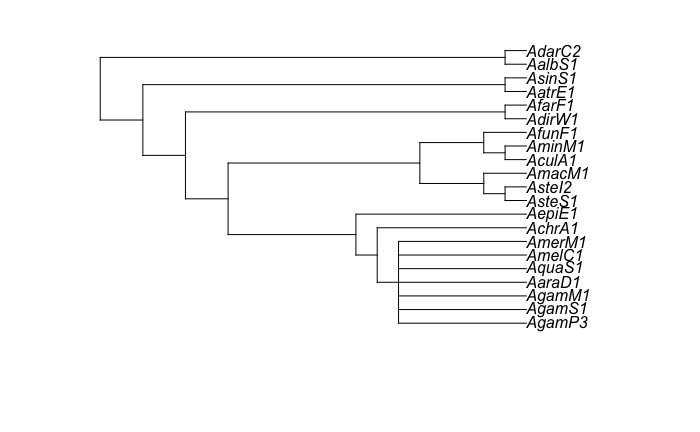

```r
neaf <- '(((((((AgamP3,AgamS1,AgamM1,AaraD1,AquaS1,AmelC1,AmerM1),AchrA1),AepiE1),(((AsteS1,AsteI2),AmacM1),((AculA1,AminM1),AfunF1))),(AdirW1,AfarF1)),(AatrE1,AsinS1)),(AalbS1,AdarC2));'
y <- read.tree(file='', text=neaf, tree.names=c('WG'))
plot(y)
```

Make tree topology PCA

```r
x[[75]] <- y
tree_type <- c(rep('amplicon', 74), 'whole genome')
Ascape <- treespace(x, nf=2)
plotGrovesD3(Ascape$pco, groups=tree_type, treeNames=c(c(0:73),'WG'))
```

[interactive chart not shown]

Let’s discard branch length info

```r
x_nolen <- lapply(x, function(l) {l$edge.length <- NULL; l$node.label <- NULL; l})
class(x_nolen) <- "multiPhylo"
Ascape <- treespace(x_nolen, nf=2)
plotGrovesD3(Ascape$pco, groups=tree_type, treeNames=c(c(0:73),'WG'))
```

[interactive chart not shown]

Looks like most of the trees are still systemaltically biased compared to the whole genome. Let’s find the difference.

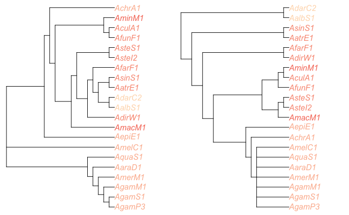

```r
plotTreeDiff(x_nolen[[11]],y)
```

Rerooting helps to see it clearer

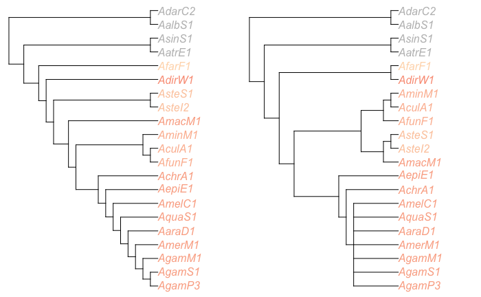

```r
plotTreeDiff(root(x_nolen[[11]],c('AalbS1','AdarC2'),r=TRUE),y)
```

But it does not affect the PCA

```r
x_reroot <- lapply(x_nolen, function(l) {root(l,c('AalbS1')); l})
class(x_reroot) <- "multiPhylo"
Ascape <- treespace(x_reroot, nf=2)
plotGrovesD3(Ascape$pco, groups=tree_type, treeNames=c(c(0:73),'WG'))
```

[interactive chart not shown]

Let’s construct a median tree from the main cluster of the trees and compare it to the whole-genome tree

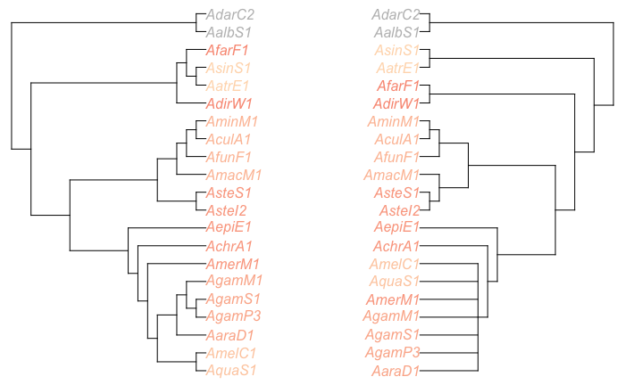

```r
main_x <- x_nolen[c(1:32,34:49,51:63,65:74)] # get rid of outliers, remembering that tree ID is 0-based, and R index is 1-based
x_med <- medTree(main_x)
plotTreeDiff(root(x_med$trees[[1]],c('AalbS1','AdarC2'),r=TRUE), y, treesFacing=TRUE, tipMatch=TRUE)
```

Assert the position of median tree makes sense

```r
main_x[[72]] <- medTree(main_x)$trees[[1]]
Ascape <- treespace(main_x, nf=2)
plotGrovesD3(Ascape$pco, groups=c(rep('amplicons',71),'median'))
```

[interactive chart not shown]

Interestingly, if we construct median tree of inital dataset with edge length, the topology of the resulting median tree will differ from both previous and the whole-genome one. The only common feature of amplicon trees differing from whole-genome tree is grouping of Anopheles and Nyssorhynchus in a monophyletic clade.

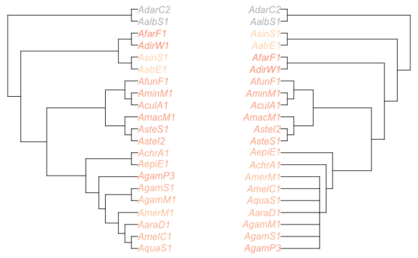

```r
main_x <- x[c(1:32,34:49,51:63,65:74)] # get rid of outliers, remembering that tree ID is 0-based, and R index is 1-based
x_med <- medTree(main_x)$trees[[1]]
x_med$edge.length <- NULL
x_med <- root(x_med,c('AalbS1','AdarC2'),r=TRUE)
plotTreeDiff(ladderize(x_med), ladderize(y), treesFacing=TRUE, tipMatch=FALSE)
```

Still, the position of the median tree remains representative

```r
main_x[[72]] <- medTree(main_x)$trees[[1]]
Ascape <- treespace(main_x, nf=2)
plotGrovesD3(Ascape$pco, groups=c(rep('amplicons',71),'median'))
```

[interactive chart not shown]

Plot distribution of tree distances (i.e., number of branch repositions) between the amplicons and the whole-genome tree

```r
Ascape <- treespace(x_nolen, nf=2)
par(mfrow=c(1,3))
hist(as.matrix(Ascape$D)[75,], main="Whole genome", xlab='dist')
hist(as.matrix(Ascape$D)[64,], main="Outlier amplicon", xlab='')
```

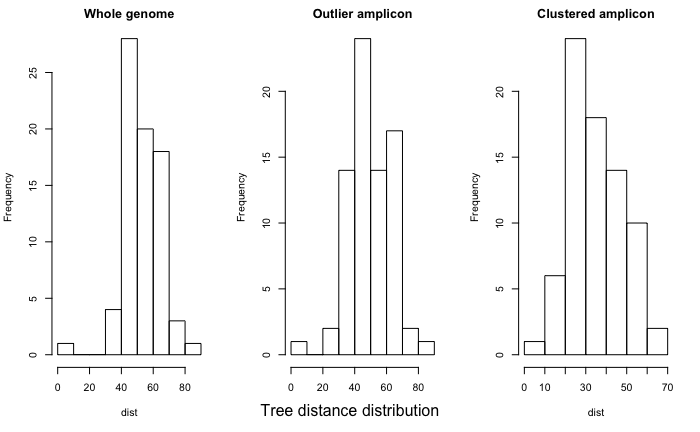

```r
hist(as.matrix(Ascape$D)[11,], main="Clustered amplicon", xlab='dist')
mtext("Tree distance distribution", side=3, line=-33, outer=TRUE)
```